# **Business Problem - Automating Email Prioritization & Responses**

## **TASK - Categorization of emails**

Your task is to write the `system_prompt` & `user_prompt` for classifying all the emails into one of the below pre-defined categories.

1. **Urgent & High-Priority Emails**:
   - Emails that require immediate action and must be addressed today.
2. **Deadline-Driven Emails**:
   - Time-sensitive emails or meeting requests that need attention today.
3. **Routine Updates & Check-ins**:
   - Emails that require review and acknowledgment without immediate action.
4. **Non-Urgent Informational Emails**:
   - Emails that can be deferred or delegated to another time or person.
5. **Personal & Social Emails**:
   - Emails that can be reviewed optionally at a later time.
6. **Spam/Unimportant Emails**:
   - Emails that are not relevant and should be filtered out.

**Note:** Your response should include only one of the above six specified categories and nothing else.

```
Example Email : 'You Won a Free iPhone 15 Pro! ?? Click to Claim'
Expected Response : 'Spam/Unimportant Emails'
```

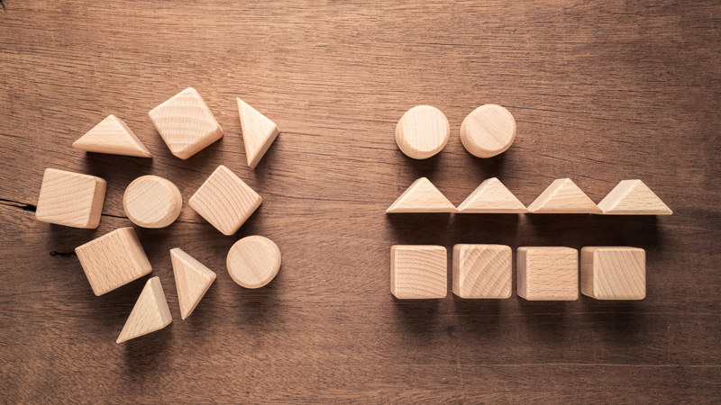

```python
# @title Code to add categories to the dataset
categories = ['Urgent & High-Priority Emails',
              'Deadline-Driven Emails',
              'Routine Updates & Check-ins',
              'Non-Urgent Informational Emails',
              'Personal & Social Emails',
              'Spam/Unimportant Emails']
```

```python
system_prompt = """Classify emails into one of the following predefined categories.
Your response should only be the name of the category, with no additional text or explanation.

Categories:

Urgent & High-Priority Emails:
Emails that require immediate action and must be addressed today.
Deadline-Driven Emails:
Time-sensitive emails or meeting requests that need attention today.
Routine Updates & Check-ins:
Emails that require review and acknowledgment without immediate action.
Non-Urgent Informational Emails:
Emails that can be deferred or delegated to another time or person.
Personal & Social Emails:
Emails related to personal matters, social events, celebrations, or informal conversations unrelated to work
Spam/Unimportant Emails:
Emails that are not relevant and should be filtered out.

Example Email: 'You Won a Free iPhone 15 Pro! Click to Claim'
Expected Response: Spam/Unimportant Emails


Example Email: 'You Won a Free iPhone 15 Pro! ?? Click to Claim'
Expected Response: Spam/Unimportant Emails

"""
```

```python
user_prompt = f"""
You are an AI email assistant. Please classify the following email into only one of the specified categories.
"""
```

````python
# @title Categorizing the emails
from tqdm import tqdm  # Import the tqdm library for the progress bar

# Ensure the 'category' column exists in the DataFrame
if 'category' not in yesterday_emails.columns:
  yesterday_emails['category'] = None  # Create the column if it does not exist


for index, row in tqdm(yesterday_emails.iterrows(), total=df.shape[0], desc='Processing emails'):
  prompt = f"""{user_prompt}
    Please find the attached email below from yesterday that need to be analyzed:
    ```
    {row.to_string()}
    ```
  """

  category_by_llm = llm(system_prompt, prompt)

  # Append the category generated by the LLM to the 'category' column in the same row
  if category_by_llm in categories:
    yesterday_emails.at[index, 'category'] = category_by_llm
  else:
    yesterday_emails.at[index, 'category'] = ""
````

```python
yesterday_emails['category'].unique()
```

```
array(['Urgent & High-Priority Emails', 'Routine Updates & Check-ins',
       'Deadline-Driven Emails', 'Non-Urgent Informational Emails',
       'Spam/Unimportant Emails', 'Personal & Social Emails'],
      dtype=object)
```

```python
category_counts = yesterday_emails['category'].value_counts()
display(category_counts)
```

| category | count |
| --- | --- |
| Routine Updates & Check-ins | 18 |
| Urgent & High-Priority Emails | 16 |
| Deadline-Driven Emails | 10 |
| Non-Urgent Informational Emails | 3 |
| Spam/Unimportant Emails | 3 |
| Personal & Social Emails | 1 |

**dtype:** int64

```python
# Display the DataFrame which has categories
yesterday_emails.head()
```

|  | date_received | sender | subject | body | main_recipient | category |
| --- | --- | --- | --- | --- | --- | --- |
| 0 | 03/03/2025 | Julia Martin | Approval Request: Budget Approval Needed by EOD | Hi Alex,\n\nI hope you're doing well. As we ap... | Alex | Urgent & High-Priority Emails |
| 1 | 03/03/2025 | Fiona White | Are Your APIs Secure? Reddit & Discord Sound t... | Hi Alex,\n\nA heated Discord discussion in the... | Alex | Routine Updates & Check-ins |
| 2 | 03/03/2025 | Samantha Lee | Approval Needed: Project Scope Adjustment for ... | Hi Alex,\n\nWeve encountered an unexpected AP... | Alex | Urgent & High-Priority Emails |
| 3 | 03/03/2025 | James Patel | Subject: Daily Update  Project Titan (March 3) | Hey Alex,\n\nQuick update on Project Titan for... | Alex | Routine Updates & Check-ins |
| 4 | 03/03/2025 | David Whitmore | [URGENT] Dashboard Syncing Issues  Production... | Hey Alex,\n\nWeve got a big issue right nowl... | Alex | Urgent & High-Priority Emails |

# **Task 1: Awareness of your email: Get to know the detailed summary of your email received**

## **1A. Executive Dashboard (Top-Level Summary of Yesterday’s Inbox)**

**Note:** Follow the instructions carefully and complete the missing sections.

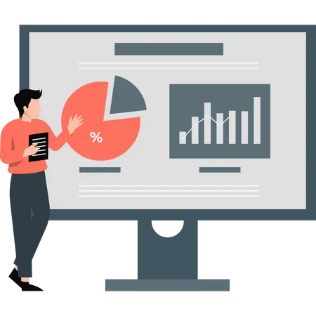

Alex’s inbox is a **delicate balance of urgent action items, strategic decisions, and routine updates**. He must **prioritize effectively**—focusing on high-impact emails first, ensuring compliance with deadlines, and delegating less critical tasks to his team.

In this step, you will generate a high-level summary of the emails received using the AI Email Secretary. The AI will categorize emails into distinct categories and generate actionable insights.

#### **TASK**

Write the `system_prompt` & `user_prompt` that will guide the AI model to generate an executive summary based on the filtered data (yesterday_emails). The prompt should:

1. Count the number of emails per category.
2. Provide a final AI summary that highlights the number of critical emails requiring immediate action and the emails which can be handled later.

```python
system_prompt = """

Generate an executive summary using the exact format as per the given instructions.
The summary must follow this exact structure and content guidelines.
All necessary counts will be provided. Your task is to accurately insert these counts into the specified placeholders (denoted by [Count] or [Sum]). Do not perform any calculations or data extraction yourself.

Executive Summary of Emails

1. **Total Number of Emails Received**: [Count]
2. **Total Number of Emails from Yesterday**: [Count]
3. **Email Breakdown by Categories:**
    - Urgent & High-Priority Emails: [Count]
    - Deadline-Driven Emails: [Count]
    - Routine Updates (Review & Acknowledge): [Count]
    - Non-Urgent Informational Emails: [Count]
    - Personal & Social Emails: [Count]
    - Spam/Unimportant Emails: [Count]
4. **AI Conclusion:**
    - Critical Emails Requiring Immediate Attention:
        - Urgent & High-Priority Emails: [Count]
        - Deadline-Driven Emails: [Count]
        - Total Critical Emails: [Sum]
    - **Emails That Can Be Reviewed Later**:
        - Routine Updates: [Count]
        - Non-Urgent Informational Emails: [Count]
        - Personal & Social Emails: [Count]
        - Spam/Unimportant Emails: [Count]
        - Total Non-Critical Emails: [Sum]

**Summary Insights:**

The inbox contains a significant number of critical emails ([Total Critical]), which require
immediate attention, including urgent requests and deadlines that are approaching. This indicates
a high workload and potential pressure to respond quickly to pressing issues. In contrast, there
are [Total Non-Critical] emails that can be reviewed later, allowing for prioritization of the
urgent matters first. It is advisable to address the urgent and deadline-driven emails promptly
to mitigate risks and ensure smooth operations.


"""
```

````python
# @title User Prompt
# Write your user prompt here
user_prompt = f"""

Generate an executive summary using the exact format in my instructions.
Your summary must follow this exact structure and content guideline.

Below is the attached DataFrame for analysis:
```
{yesterday_emails.to_string()}
```
"""
````

```python
# @title  Calling the model and display the summary


response_1 = llm(system_prompt, user_prompt)        # llm is the model using gpt-4o-mini
response_1

from IPython.display import display, Markdown
display(Markdown(response_1))
```

Executive Summary of Emails

1. **Total Number of Emails Received**: 51

3. **Email Breakdown by Categories:**

   - Deadline-Driven Emails: 10

   - Spam/Unimportant Emails: 3

4. **AI Conclusion:**

   - Critical Emails Requiring Immediate Attention:

     - Deadline-Driven Emails: 10

   - **Emails That Can Be Reviewed Later**:

     - Spam/Unimportant Emails: 3

**Sample Output Example**

A structured summary with the number of emails in each category and key action points.

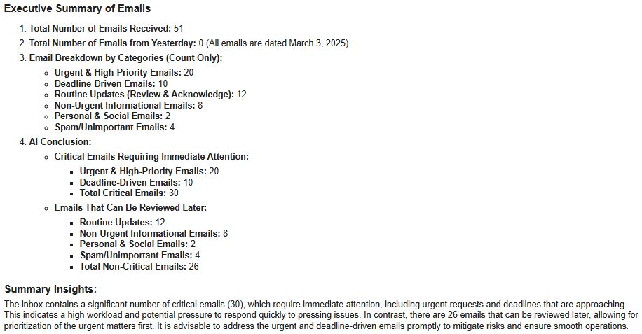

## **1B. Urgent Emails from Yesterday (🛑 Must-Do First Today)**

**Note:** Follow the instructions carefully and complete the missing sections.

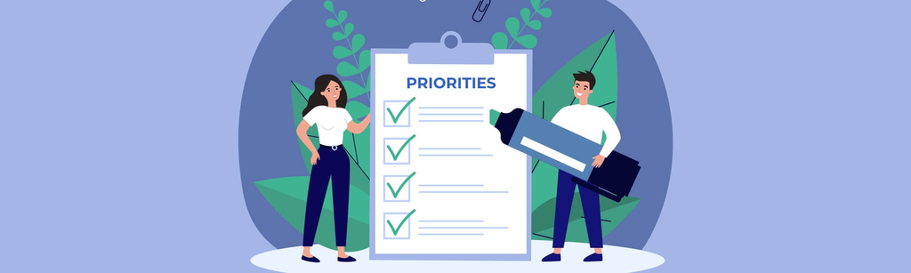

**Urgent & High-Priority Emails (Requires Immediate Action)**

**Examples of Expected Outputs**

- **Subject:** URGENT: Critical System Downtime – Immediate Attention Required

  **Received:** 03/03/2025

  **Sender Name:** David Whitmore

  **Summary:** David reports a major outage with the Orion Analytics Dashboard, impacting multiple manufacturing lines.

  **Next Step:** Provide an immediate resolution or workaround by 12 PM EST today and escalate to the engineering team if necessary.
- **Subject:** URGENT: Medication Alerts Not Firing – This is Dangerous

  **Received:** 03/03/2025

  **Sender Name:** Rachel Thompson

  **Summary:** Rachel highlights a serious issue where automated medication alerts are not firing for ICU patients, posing a safety risk.

  **Next Step:** Join the emergency call and prioritize fixing the issue immediately.
- **Subject:** Approval Request: Travel Budget for AWS Summit 2025

  **Received:** 03/03/2025

  **Sender Name:** Olivia Chen

  **Summary:** Olivia requests approval for travel expenses for two team members to attend the AWS Summit 2025.

  **Next Step:** Review the request and confirm if you can proceed with the budget approval.

#### **TASK**

Write the `system_prompt` & `user_prompt` that will guide the AI to write a Summary and the Next Step to be taken for the respective email, for all urgent and high-priority emails from the filtered data (urgent_emails)

Ensure each email summary follows this format:

- Subject:
- Received:
- Sender Name:
- Summary:
- Next Step: (it should be particular to that email)

**Note :-** Apply instructions regarding Yesterbox Rule : Confirm that these emails were received yesterday and are part of today's to-do list.

```python
# @title System Prompt

# Write your system prompt here
system_prompt = """Apply the given instuctions regarding Yesterbox Rule:
Only process Urgent & High-Priority emails that were received yesterday and are part of today's to-do list.


Ensure each email summary follows this exact format:
Here are the Urgent & High-Priority emails that require your attention or intervention, as per the provided records. All emails listed were received yesterday and are part of today's to-do list.

**Urgent & High-Priority Emails**

  1.  **Subject:** [Email subject]
      **Received:** [Date received]
      **Sender Name:** [Sender's name]
      **Summary:** [write a one sentnce summary including Sender's name]
      **Next Step:** [Specific action should be particular to the email]


"""
```

**Question:** Construct the `user_prompt` that will pass the filtered dataset to the AI model for identifying urgent emails.

```python
# Filtering out the emails that are urgent and high-priority
urgent_emails = yesterday_emails[yesterday_emails['category'] == 'Urgent & High-Priority Emails']
```

````python
# @title User Prompt

# Write your user prompt here
user_prompt = f"""


Write a Summary and the Next Step to be taken for all urgent and high-priority emails


Below is the attached DataFrame, which contains all the emails that needs to be summarized:
```
{urgent_emails.to_string()}
```
"""
````

```python
# @title  Calling the model and display the summary

response_2 = llm(system_prompt, user_prompt)

from IPython.display import display, Markdown
display(Markdown(response_2))
```

Here are the Urgent & High-Priority emails that require your attention or intervention, as per the provided records. All emails listed were received yesterday and are part of today's to-do list.

**Urgent & High-Priority Emails**

1. **Subject:** Approval Request: Budget Approval Needed by EOD  
   **Received:** 03/03/2025  
   **Sender Name:** Julia Martin  
   **Summary:** Julia Martin is requesting your approval for the budget by the end of the day to avoid delays in project execution.  
   **Next Step:** Review the attached budget breakdown and provide your approval.

2. **Subject:** Approval Needed: Project Scope Adjustment for Acme Corp Integration  
   **Received:** 03/03/2025  
   **Sender Name:** Samantha Lee  
   **Summary:** Samantha Lee is seeking your confirmation to proceed with a proposed adjustment to the project scope due to an unexpected API limitation.  
   **Next Step:** Confirm if the team can proceed with the proposed change.

3. **Subject:** [URGENT] Dashboard Syncing Issues – Production Metrics Missing  
   **Received:** 03/03/2025  
   **Sender Name:** David Whitmore  
   **Summary:** David Whitmore is reporting critical issues with the production metrics not syncing on the dashboard and needs immediate resolution.  
   **Next Step:** Investigate the syncing issue and provide an update within 24 hours.

4. **Subject:** Blocking Issue Alert – Client Data Sync Failing  
   **Received:** 03/03/2025  
   **Sender Name:** David Kurien  
   **Summary:** David Kurien has alerted you about a major problem with client transaction data not syncing, requiring urgent action.  
   **Next Step:** Determine whether to roll back the last deployment or wait for further investigation.

5. **Subject:** URGENT: Approval Needed for 2-Week Extension on Acme Corp Deployment  
   **Received:** 03/03/2025  
   **Sender Name:** Tanya Patel  
   **Summary:** Tanya Patel is requesting your approval for a two-week extension on the Acme Corp deployment due to internal team conflicts.  
   **Next Step:** Decide on the extension request and communicate your decision.

6. **Subject:** System Crashing During Shift Changes – URGENT  
   **Received:** 03/03/2025  
   **Sender Name:** David Whitmore  
   **Summary:** David Whitmore is reporting that the Orion Manufacturing System is crashing during shift changes, blocking operations.  
   **Next Step:** Assign a team member to investigate the issue and join the scheduled call.

7. **Subject:** ?? Security Risk – Critical Patch Delayed  
   **Received:** 03/03/2025  
   **Sender Name:** Bob Smith  
   **Summary:** Bob Smith is informing you about a high-risk delay in the security patch rollout and is seeking your guidance on how to proceed.  
   **Next Step:** Decide whether to push the patch with risks or delay further.

8. **Subject:** URGENT: Production Halt – Machine Control System Unresponsive  
   **Received:** 03/03/2025  
   **Sender Name:** David Whitmore  
   **Summary:** David Whitmore is reporting a critical issue with the Machine Control System being unresponsive, halting production.  
   **Next Step:** Call David immediately to discuss the situation and next steps.

9. **Subject:** [High Priority] Authentication Failing for Multiple Users  
   **Received:** 03/03/2025  
   **Sender Name:** Mark Davidson  
   **Summary:** Mark Davidson is reporting an authentication issue affecting multiple engineers and needs access restored urgently.  
   **Next Step:** Investigate the authentication issue and restore access as soon as possible.

10. **Subject:** URGENT: Approval for Security Audit Vendor – Time-Sensitive  
    **Received:** 03/03/2025  
    **Sender Name:** Rachel Lim  
    **Summary:** Rachel Lim is following up on the approval for the security audit contract, which is time-sensitive.  
    **Next Step:** Confirm the approval for the contract with CyberShield.

11. **Subject:** URGENT: Critical System Downtime – Immediate Attention Required  
    **Received:** 03/03/2025  
    **Sender Name:** David Whitmore  
    **Summary:** David Whitmore is reporting a major outage with the Orion Analytics Dashboard that needs immediate resolution.  
    **Next Step:** Provide a status update within the next hour and escalate if necessary.

12. **Subject:** URGENT: Overdue Invoice Approval for Cloud Services  
    **Received:** 03/03/2025  
    **Sender Name:** Sarah Mitchell  
    **Summary:** Sarah Mitchell is requesting urgent approval for an overdue invoice to avoid penalties.  
    **Next Step:** Approve the invoice for CloudOps Solutions as soon as possible.

13. **Subject:** URGENT: Medication Alerts Not Firing – This is Dangerous  
    **Received:** 03/03/2025  
    **Sender Name:** Rachel Thompson  
    **Summary:** Rachel Thompson is reporting a critical issue with medication alerts not firing, posing a patient safety risk.  
    **Next Step:** Join the emergency call and address the issue immediately.

14. **Subject:** Urgent: Performance Degradation in Production System  
    **Received:** 03/03/2025  
    **Sender Name:** Nathan Ellis  
    **Summary:** Nathan Ellis is reporting a critical slowdown in the production environment and is seeking your approval for an emergency scale-up.  
    **Next Step:** Approve the emergency scale-up and decide on client communication.

**Sample Output Example**

A list of urgent emails with detailed summaries and next steps.

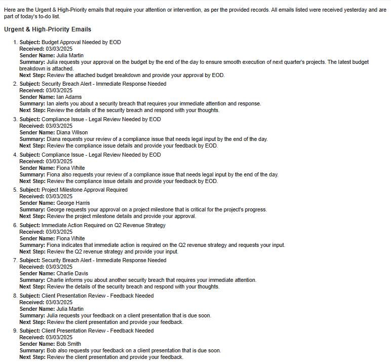

## **1C: Deadline-Driven Emails from Yesterday (⚡ Needs Attention Today)**

**Note:** Follow the instructions carefully and complete the missing sections.

[figure not shown]

**Deadline-Driven Emails (Needs to be Addressed Today)**

**Examples**

- **Subject: Q2 Revenue Strategy - Immediate Action Required**

  **From:** George Harris (Director of Strategy)

  *Summary:* Leadership expects a finalized strategy document by EOD to align with upcoming board discussions.
- **Subject: Client Presentation Review - Feedback Needed**

  **From:** George Harris (Senior Sales Executive)

  *Summary:* Feedback is required on a key client pitch deck before the presentation scheduled for tomorrow.
- **Subject: Employee Engagement Survey Reminder**

  **From**: Charlie Davis (HR Manager)

  *Summary:* Employees must complete the engagement survey before the end of the day to finalize workplace improvement initiatives.

### **TASK**

Write the `system_prompt` and `user_prompt` that will guide the AI model to summarize and generate an appropriate next step for time-sensitive and deadline-driven emails. The response should include the following information:

- **Subject**: (The email's subject line)
- **Received**: (The time and date the email was received)
- **Sender Name**: (Name of the person who sent the email)
- **Summary**: (A concise summary of the email's content)
- **Next Step**: (A specific action that needs to be taken based on the email, with a clear focus on meeting deadlines)

Each email must explicitly mention a **specific deadline** for today or require action to meet an impending delivery timeline.

The final count of Deadline-Driven emails with summary

**Question:** Construct the `user_prompt` to pass the filtered dataset and request deadline-driven emails with next steps.

Ensure that:

- These emails are separate from the Urgent & High-Priority Emails already covered.
- **Exclude** any emails already categorized under **Urgent & High-Priority**.
- Each email must mention a **specific deadline** for today or require action to meet a delivery timeline.
- The final count of Deadline-Driven emails + Urgent & High-Priority emails should equal the Critical Emails count in the Executive Summary.

```python
# @title System Prompt

# Write your system prompt here
system_prompt = """

Summarize each of the following Deadline-Driven emails. These emails are separate from Urgent & High-Priority emails already handled.
Do not stop until all are summarized.
The Final Count must reflect the actual number of emails in the DataFrame provided.
Only process Deadline-Driven emails. Do not add anything outside this format.

Follow this exact format for each email:

**Deadline-Driven Emails Summary**

[Number]. **[Email Exceeding Deadline / Email Requiring Action Today]**
    - **Subject:** [Email subject line]
    - **Received:** [Date received]
    - **Sender Name:** [Sender's full name]
    - **Summary:** [One sentence summary]
    - **Next Step:** [Specific action to meet the deadline]

(Repeat the above format for all {len(deadline_emails)} emails)

**Final Count of Deadline-Driven Emails**
- Total Deadline-Driven Emails: [Count] (including [Count] that has exceeded its deadline)

**Summary of Actionable Items**
- [List all distinct next steps from the summarized emails]

"""
```

```python
# Filtering out the emails that are Time Sensitive & Deadline-Driven
deadline_emails = yesterday_emails[yesterday_emails['category'] == 'Deadline-Driven Emails']
```

````python
# @title User Prompt


# Write your user prompt here
user_prompt = f"""

Smmarize all Deadline-Driven emails received yesterday.


Below is the attached DataFrame, which contains all the emails that needs to be summarized:
```
{deadline_emails.to_string()}
```
"""
````

```python
# @title  Calling the model and display the summary

response_3 = llm(system_prompt, user_prompt)

from IPython.display import display, Markdown
display(Markdown(response_3))
```

**Deadline-Driven Emails Summary**

1. **Email Exceeding Deadline**

   - **Subject:** Approval Request: Additional AWS Resources for Project Orion

   - **Received:** 03/03/2025

   - **Sender Name:** Nathan Cole

   - **Summary:** Nathan requests approval for additional AWS resources to avoid performance bottlenecks.

   - **Next Step:** Approve by March 7 to avoid service degradation.

2. **Email Requiring Action Today**

   - **Subject:** Approval Request: Dev Environment Upgrade for Faster Builds

   - **Received:** 03/03/2025

   - **Sender Name:** Kevin Tran

   - **Summary:** Kevin requests approval for upgraded cloud servers to speed up development.

   - **Next Step:** Approve by March 10 to deploy the upgrade.

3. **Email Requiring Action Today**

   - **Subject:** Approval Request: Travel Budget for AWS Summit 2025

   - **Received:** 03/03/2025

   - **Sender Name:** Olivia Chen

   - **Summary:** Olivia requests approval for travel budget for the AWS Summit 2025.

   - **Next Step:** Confirm if they can proceed with the budget.

**Summary of Actionable Items**

- Approve additional AWS resources by March 7.

- Approve Dev environment upgrade by March 10.

- Confirm travel budget for AWS Summit 2025.

**Sample Output Example**

A list of deadline-driven emails with summaries and next steps.

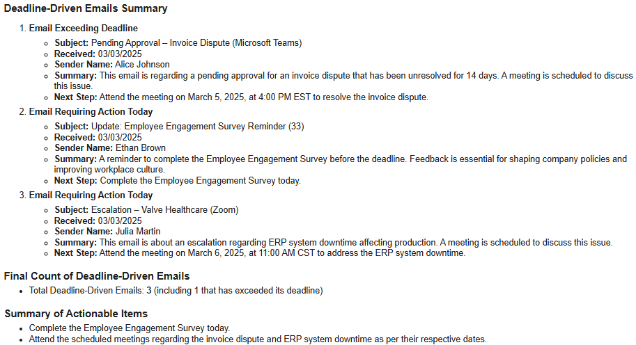

# **Task 2: AI-Generated "First Response" Drafts for Critical Email**

**Note:** Follow the instructions carefully and complete the missing sections.

#### **Critical Emails** are combination of the **Urgent & High-Priority Emails + Deadline-Driven Emails**

**Objective:** Generate AI-drafted responses for critical emails received yesterday.

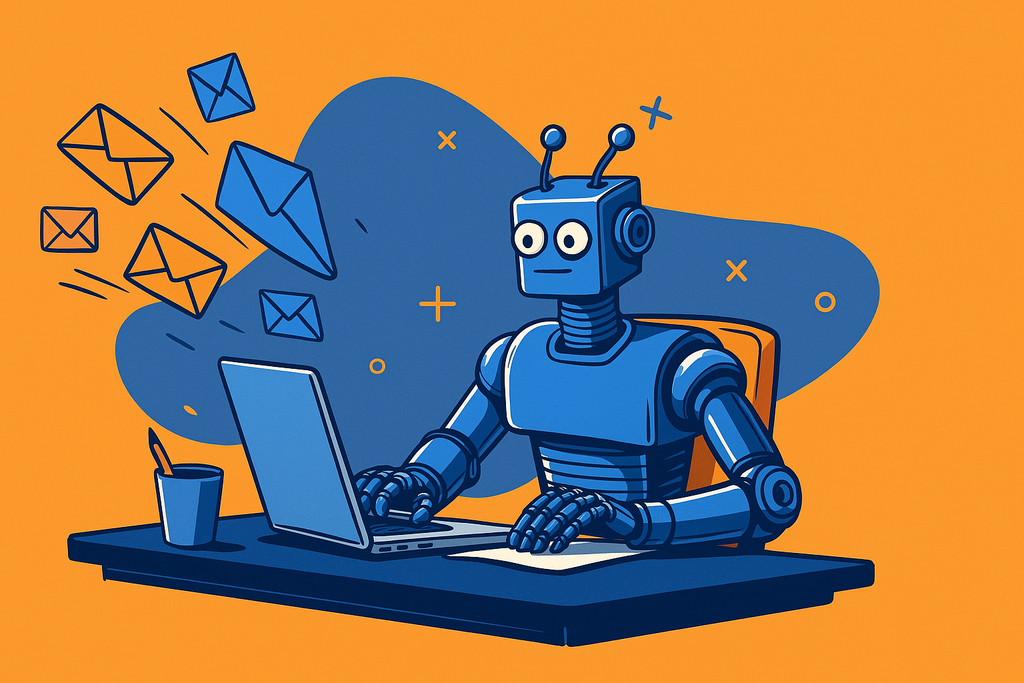

#### **TASK**

Write the `system_prompt` & `user_prompt` that will guide the AI model to generate a professional "First Response Draft" for the High Priority Emails.

The response should include:

- Acknowledge the sender’s request and contextually relevant.
- Address the key points, queries, or actions requested in the original email.
- Provide a clear next step or decision.
- Maintain a polite, formal, and professional tone, aligned with corporate communication standards.

The format of the Draft should have:

- Subject: (Subject of the email)
- Sender Name: (Name of the Sender)
- AI Drafted Reply: (Your AI-generated response)

```python
# @title System Prompt
# Write your system prompt here
system_prompt = """

Draft a professional "First Response Draft" for Urgent & High-Priority Emails and Deadline-Driven Emails received yesterday.

The response must include:
- Acknowledge the sender request and contextually relevant.
- Address the key points, queries, or actions requested in the original email.
- Provide a clear next step or decision.
- Maintain a polite, formal, and professional tone, aligned with corporate communication standards.


The format of each respnse must have:

**Subject:** (Subject of the email)
**Sender Name:** (Name of the Sender)
**AI Drafted Reply:** (Your AI-generated response starting with sender's name)

Separate each email response with ---

"""
```

```python
# Filtering out the emails that are Critical Emails, i.e. ('Urgent & High-Priority Emails' + 'Deadline-Driven Emails')
critical_emails = yesterday_emails[yesterday_emails['category'].isin(['Urgent & High-Priority Emails', 'Deadline-Driven Emails'])]
```

````python
# @title User Prompt

# You may format the classifying method according to you


# Write your user prompt here
user_prompt = f"""

Draft a professional First Response for each of the critical emails.

Below is the attached DataFrame, which contains all the critical emails that needs to be replied:
```
{critical_emails.to_string()}
```
"""
````

```python
# @title  Calling the model and display the summary

response_4 = llm(system_prompt, user_prompt)
from IPython.display import display, Markdown
display(Markdown(response_4))
```

**Subject:** Approval Request: Budget Approval Needed by EOD  
**Sender Name:** Julia Martin  
**AI Drafted Reply:** Dear Julia,

Thank you for your email regarding the budget approval needed by the end of today. I appreciate your diligence in ensuring that we stay on track for the upcoming quarter's projects.

I have reviewed the attached budget breakdown and have no concerns at this time. I will proceed with the approval shortly to facilitate a smooth execution of the projects.

Thank you for your prompt attention to this matter.

Best regards,  
Alex

**Subject:** Approval Needed: Project Scope Adjustment for Acme Corp Integration  
**Sender Name:** Samantha Lee  
**AI Drafted Reply:** Dear Samantha,

Thank you for bringing the project scope adjustment for Acme Corp's integration to my attention. I understand the necessity of adapting our approach due to the unexpected API limitations.

I approve the proposed change to implement a message queue-based approach, as it ensures we maintain our timeline without compromising performance. Please proceed with the implementation.

If further discussions are needed, feel free to reach out.

Best regards,  
Alex

**Subject:** [URGENT] Dashboard Syncing Issues – Production Metrics Missing  
**Sender Name:** David Whitmore  
**AI Drafted Reply:** Dear David,

I appreciate your prompt notification regarding the dashboard syncing issues. I understand the urgency of the situation, and I will have my team investigate the discrepancies in the production metrics immediately.

We will aim to provide you with an update within the next 24 hours. If necessary, I will coordinate with our IT team to ensure we resolve this issue as quickly as possible.

Thank you for your patience.

Best regards,  
Alex

**Subject:** Approval Request: Additional AWS Resources for Project Orion  
**Sender Name:** Nathan Cole  
**AI Drafted Reply:** Dear Nathan,

Thank you for your email regarding the need for additional AWS resources for Project Orion. I understand the importance of scaling up to avoid performance bottlenecks.

I approve the increase in AWS instance count by 20% to ensure we meet our Q2 deadlines. Please proceed with the necessary arrangements.

Best regards,  
Alex

**Subject:** Blocking Issue Alert – Client Data Sync Failing  
**Sender Name:** David Kurien  
**AI Drafted Reply:** Dear David,

Thank you for alerting me to the client data sync issue. I understand the critical nature of this problem and the impact it has on our operations.

I recommend that we initiate a war room call to address this issue immediately. Please coordinate with your team and let me know a suitable time for us to discuss the next steps, including whether we should roll back the recent deployment.

Thank you for your swift action on this matter.

Best regards,  
Alex

**Subject:** URGENT: Approval Needed for 2-Week Extension on Acme Corp Deployment  
**Sender Name:** Tanya Patel  
**AI Drafted Reply:** Dear Tanya,

Thank you for your email regarding the request for a two-week extension on the Acme Corp deployment. I understand the challenges faced due to internal team conflicts.

I approve the extension to March 1, 2025, to ensure that we deliver a high-quality product. Please communicate this change to the team and keep me updated on the progress.

Best regards,  
Alex

**Subject:** System Crashing During Shift Changes – URGENT  
**Sender Name:** David Whitmore  
**AI Drafted Reply:** Dear David,

Thank you for bringing the system crashing issue to my attention. I understand the urgency and the impact this has on operations.

I will have my team investigate this matter immediately. I appreciate your invitation for a call at 3 PM EST, and I will ensure that the relevant team members are present to discuss the situation further.

Thank you for your patience as we work to resolve this.

Best regards,  
Alex

**Subject:** ?? Security Risk – Critical Patch Delayed  
**Sender Name:** Bob Smith  
**AI Drafted Reply:** Dear Bob,

Thank you for your email regarding the delay in the security patch rollout. I understand the risks associated with this situation.

I recommend that we proceed with the patch rollout despite the risks, as compliance is critical. Please ensure that the infra team communicates the potential vulnerabilities to all stakeholders.

Let me know if you need any further assistance.

Best regards,  
Alex

**Subject:** URGENT: Production Halt – Machine Control System Unresponsive  
**Sender Name:** David Whitmore  
**AI Drafted Reply:** Dear David,

Thank you for your urgent notification regarding the unresponsive Machine Control System. I understand the critical nature of this issue and the immediate need for resolution.

I will have my team prioritize this matter and will reach out to you shortly with updates. Please keep your team on standby for any necessary communications.

Thank you for your swift action on this.

Best regards,  
Alex

**Subject:** EBR Meeting Invite – Sentinel Cyber Inc. (Microsoft Teams)  
**Sender Name:** Lisa Taylor  
**AI Drafted Reply:** Dear Lisa,

Thank you for the invitation to the EBR meeting on March 14, 2025. I appreciate the agenda you have outlined.

I will ensure that the necessary team members are available to discuss the topics listed. If there are any additional points you would like to address, please let me know.

Best regards,  
Alex

**Subject:** Scheduling Q1 Executive Business Review (EBR) – Sentinel Cyber Inc.  
**Sender Name:** Alex Carter  
**AI Drafted Reply:** Dear Mark,

Thank you for your email regarding the scheduling of the Q1 Executive Business Review. I confirm that March 12, 2025, at 10 AM EST works for us.

I will also ensure that the agenda includes the additional points you mentioned. Looking forward to our discussion.

Best regards,  
Alex

**Subject:** [High Priority] Authentication Failing for Multiple Users  
**Sender Name:** Mark Davidson  
**AI Drafted Reply:** Dear Mark,

Thank you for bringing the authentication issue to my attention. I understand the urgency of restoring access for the engineers.

I will have my team investigate this matter immediately and will keep you updated on our progress. Thank you for your patience as we work to resolve this.

Best regards,  
Alex

**Subject:** Approval Needed: Purchase of Design Tool for Engineering Team  
**Sender Name:** Liam Ross  
**AI Drafted Reply:** Dear Liam,

Thank you for your request regarding the purchase of Adobe Creative Cloud licenses for the engineering team. I understand the need for these tools for UI/UX work.

I will review the justification and get back to you shortly with a decision. Thank you for your patience.

Best regards,  
Alex

**Subject:** EBR Meeting Invite – Acme Manufacturing (Google Meet)  
**Sender Name:** Ethan Brown  
**AI Drafted Reply:** Dear Ethan,

Thank you for the invitation to the EBR meeting on March 18, 2025. I appreciate the agenda you have outlined.

I will ensure that the necessary team members are available to discuss the topics listed. If there are any additional points you would like to address, please let me know.

Best regards,  
Alex

**Subject:** URGENT: Approval for Security Audit Vendor – Time-Sensitive  
**Sender Name:** Rachel Lim  
**AI Drafted Reply:** Dear Rachel,

Thank you for your email regarding the approval for the security audit contract with CyberShield. I understand the urgency of this matter.

I will prioritize this request and provide you with a confirmation by March 7. Thank you for your patience.

Best regards,  
Alex

**Subject:** URGENT: Critical System Downtime – Immediate Attention Required  
**Sender Name:** David Whitmore  
**AI Drafted Reply:** Dear David,

Thank you for your urgent notification regarding the critical system downtime. I understand the impact this has on operations.

I will have my team investigate this issue immediately and will provide you with a status update within the hour. Thank you for your patience as we work to resolve this.

Best regards,  
Alex

**Subject:** Follow-Up: Server Downtime - Critical Fix Required  
**Sender Name:** Bob Smith  
**AI Drafted Reply:** Dear Bob,

Thank you for your follow-up regarding the server downtime. I understand the urgency of resolving this issue.

I will review the attached logs and provide any insights that could expedite the fix. Thank you for your prompt attention to this matter.

Best regards,  
Alex

**Subject:** Escalation – Valve Healthcare (Zoom)  
**Sender Name:** Julia Martin  
**AI Drafted Reply:** Dear Julia,

Thank you for the escalation regarding the ERP system downtime affecting production. I understand the urgency of this situation.

I will ensure that the necessary team members are prepared for the meeting on March 6, 2025, at 11:00 AM CST. Thank you for your diligence in addressing this matter.

Best regards,  
Alex

**Subject:** Approval Request: Dev Environment Upgrade for Faster Builds  
**Sender Name:** Kevin Tran  
**AI Drafted Reply:** Dear Kevin,

Thank you for your request regarding the upgrade of the development environment. I understand the need for faster build times.

I will review the proposed upgrade and provide you with a decision by March 10. Thank you for your patience.

Best regards,  
Alex

**Subject:** RE: Scheduling Q1 Executive Business Review (EBR) – Acme Manufacturing  
**Sender Name:** Daniel Goodpacker  
**AI Drafted Reply:** Dear Daniel,

Thank you for confirming the date for the EBR on March 18 at 3 PM CST. I appreciate your input on the agenda.

I will ensure that the additional topics are included and that your CIO, Samantha Brooks, is invited to join the discussion. Looking forward to our meeting.

Best regards,  
Alex

**Subject:** URGENT: Overdue Invoice Approval for Cloud Services  
**Sender Name:** Sarah Mitchell  
**AI Drafted Reply:** Dear Sarah,

Thank you for your email regarding the overdue invoice from CloudOps Solutions. I understand the urgency of this matter.

I will prioritize the approval to avoid any late fees or service disruptions. Thank you for your diligence in following up.

Best regards,  
Alex

**Subject:** URGENT: Medication Alerts Not Firing – This is Dangerous  
**Sender Name:** Rachel Thompson  
**AI Drafted Reply:** Dear Rachel,

Thank you for your urgent notification regarding the medication alerts not firing for ICU patients. I understand the critical nature of this issue.

I will join the emergency call in 30 minutes to discuss the immediate steps we need to take. Thank you for your swift action on this matter.

Best regards,  
Alex

**Subject:** Approval Request: Travel Budget for AWS Summit 2025  
**Sender Name:** Olivia Chen  
**AI Drafted Reply:** Dear Olivia,

Thank you for your request regarding the travel budget for the AWS Summit 2025. I understand the potential benefits of this opportunity for the DevOps team.

I will review the estimated costs and provide you with a decision shortly. Thank you for your patience.

Best regards,  
Alex

**Subject:** Daily Stand-up – Frontend Team (Microsoft Teams)  
**Sender Name:** Helen Paul  
**AI Drafted Reply:** Dear Helen,

Thank you for the invitation to the daily stand-up for the Frontend Team on March 4, 2025. I appreciate the agenda item regarding the UI bugs reported in Valve Healthcare's mobile dashboard.

I will ensure that the necessary team members are available for the meeting. Thank you for your diligence in addressing this matter.

Best regards,  
Alex

**Subject:** Pending Approval – Invoice Dispute (Microsoft Teams)  
**Sender Name:** Alice Johnson  
**AI Drafted Reply:** Dear Alice,

Thank you for the invitation to discuss the pending invoice dispute on March 5, 2025. I understand the importance of resolving this matter promptly.

I will ensure that I am available for the meeting and will review the relevant details beforehand. Thank you for your diligence in following up.

Best regards,  
Alex

**Subject:** Urgent: Performance Degradation in Production System  
**Sender Name:** Nathan Ellis  
**AI Drafted Reply:** Dear Nathan,

Thank you for your urgent notification regarding the performance degradation in the production system. I understand the critical nature of this issue.

I approve the emergency scale-up of the database instance to address the slowdown. Additionally, I recommend that we send a proactive update to clients regarding the situation. Please coordinate with your team and keep me updated on the progress.

Thank you for your swift action on this matter.

Best regards,  
Alex

**Sample Output Example**

A list of AI-drafted resoponses for the critical emails received yesterday with detailed summaries and next steps.

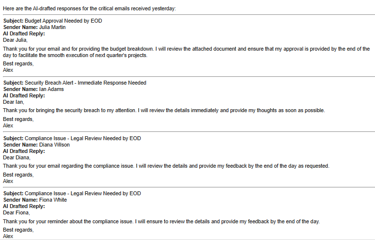

# **Task 3: Evaluation**

**Note:** Follow the instructions carefully and complete the missing sections.

[figure not shown]

## **Evaluation of Prompt Outputs with LLM-as-a-Judge**

**1. Introduction**

Evaluating the quality of prompts using LLM-as-a-Judge involves leveraging a more advanced Language Model (LLM) to assess the quality, correctness, and effectiveness of responses generated by another LLM or the same model. This method provides automated, consistent, and scalable qualitative and quantitative evaluations.

The evaluation process will:

- Use LLM-as-a-Judge to rate prompt outputs on predefined criteria.
- Automate scoring and feedback generation.
- Provide insights for prompt refinement.

Large Language Models (LLMs) can be used not only to generate content but also to **evaluate** the quality of generated responses.

### **2. Evaluation Criteria**

We will evaluate the prompt outputs based on the following key dimensions:

Rate the given **summary** on a scale of 1 to 5 for the following criteria:

- **Relevance**: How well does the **summary** address the input query or task? Identify the key information that is captured or missed. Provide a score from 1 to 5 along with Justification
- **Clarity**: How clear and understandable is the **summary**? Highlight any confusing or ambiguous phrases. Provide a score from 1 to 5 along with Justification
- **Actionability**: Does the **summary** provide clear next steps or actionable information? Provide a score from 1 to 5 along with Justification

Additionally, the LLM will be asked to provide insights in the following areas:

- **Strengths**: Highlight the key strengths of the summary.
- **Improvements**: Suggest 1-2 areas for improvement.
- **Overall Justification**: Provide a 2-3 line summary evaluation, including key observations.

#### **TASK**

Your task is to write the `system_prompt` & `user_prompt` for the above mentioned 6 criteria also note to extarct the response strictly in **JSON format**

```
Eg.Provide your evaluation strictly in JSON format:

{
  "Relevance": {"score": "", "justification": ""},
  "Clarity": {"score": "", "justification": ""},
  "Actionability": {"score": "", "justification": ""},
  "Strengths": "",
  "Improvements": "",
  "Overall_Justification": ""
}
```

```python
# @title Evaluation System Prompt

eval_system_prompt = """

Rate the given summary on the following criteria, each on a scale of 1 to 5:

Relevance: How well does the summary address the email's content?
Clarity: How clear and understandable is the summary?
Actionability: Does the summary provide clear next steps?

Additionally, provide insights in the following areas:

Strengths: Highlight the key strengths of the summary.
Improvements: Suggest 1-2 areas for improvement.
Overall Justification: Provide a 2-3 line summary evaluation, including key observations.

Return the evaluation in this exact JSON format:
{
  "Relevance": {"score": "", "justification": ""},
  "Clarity": {"score": "", "justification": ""},
  "Actionability": {"score": "", "justification": ""},
  "Strengths": "",
  "Improvements": "",
  "Overall_Justification": ""
}

"""
```

```python
# @title Evaluation User Prompt

eval_user_prompt = f"""

Evaluate the quality of AI-generated email response drafts. You must respond only in valid JSON format with no additional text.


"""
```

````python
# @title Evaluation Function & User Prompt

def evaluate_summary(eval_system_prompt, eval_user_prompt, summary, eval_model="gpt-4o-mini"):
    try:

        modified_prompt = f""" {eval_user_prompt}
                          Here is the summary:
                          ```
                          {summary}
                          ```
                          """

        eval_response = client.chat.completions.create(
            model=eval_model,
            messages=[
                {"role": "system", "content": eval_system_prompt},
                {"role": "user", "content": modified_prompt}
            ],
            temperature=0
        )
        return eval_response.choices[0].message.content.strip()

    except Exception as e:
        print(f"Error evaluating prompt: {e}")
        return "{}"  # Return empty JSON structure on error
````

```python
responses = response_4.split("---")            # splitting response on the basis of delimiter, so we get each response for the email indivisually
for _ in responses[1:-1]:                      # Excluding First and Last Element as they are nothing but blanks .i.e. (' ')
  display(Markdown(_))
  print("+"*100)
```

**Subject:** Approval Request: Budget Approval Needed by EOD  
**Sender Name:** Julia Martin  
**AI Drafted Reply:** Dear Julia,

Thank you for your email regarding the budget approval needed by the end of today. I appreciate your diligence in ensuring that we stay on track for the upcoming quarter's projects.

I have reviewed the attached budget breakdown and have no concerns at this time. I will proceed with the approval shortly to facilitate a smooth execution of the projects.

Thank you for your prompt attention to this matter.

Best regards,  
Alex

```
++++++++++++++++++++++++++++++++++++++++++++++++++++++++++++++++++++++++++++++++++++++++++++++++++++
```

**Subject:** Approval Needed: Project Scope Adjustment for Acme Corp Integration  
**Sender Name:** Samantha Lee  
**AI Drafted Reply:** Dear Samantha,

Thank you for bringing the project scope adjustment for Acme Corp's integration to my attention. I understand the necessity of adapting our approach due to the unexpected API limitations.

I approve the proposed change to implement a message queue-based approach, as it ensures we maintain our timeline without compromising performance. Please proceed with the implementation.

If further discussions are needed, feel free to reach out.

Best regards,  
Alex

```
++++++++++++++++++++++++++++++++++++++++++++++++++++++++++++++++++++++++++++++++++++++++++++++++++++
```

**Subject:** [URGENT] Dashboard Syncing Issues – Production Metrics Missing  
**Sender Name:** David Whitmore  
**AI Drafted Reply:** Dear David,

I appreciate your prompt notification regarding the dashboard syncing issues. I understand the urgency of the situation, and I will have my team investigate the discrepancies in the production metrics immediately.

We will aim to provide you with an update within the next 24 hours. If necessary, I will coordinate with our IT team to ensure we resolve this issue as quickly as possible.

Thank you for your patience.

Best regards,  
Alex

```
++++++++++++++++++++++++++++++++++++++++++++++++++++++++++++++++++++++++++++++++++++++++++++++++++++
```

**Subject:** Approval Request: Additional AWS Resources for Project Orion  
**Sender Name:** Nathan Cole  
**AI Drafted Reply:** Dear Nathan,

Thank you for your email regarding the need for additional AWS resources for Project Orion. I understand the importance of scaling up to avoid performance bottlenecks.

I approve the increase in AWS instance count by 20% to ensure we meet our Q2 deadlines. Please proceed with the necessary arrangements.

Best regards,  
Alex

```
++++++++++++++++++++++++++++++++++++++++++++++++++++++++++++++++++++++++++++++++++++++++++++++++++++
```

**Subject:** Blocking Issue Alert – Client Data Sync Failing  
**Sender Name:** David Kurien  
**AI Drafted Reply:** Dear David,

Thank you for alerting me to the client data sync issue. I understand the critical nature of this problem and the impact it has on our operations.

I recommend that we initiate a war room call to address this issue immediately. Please coordinate with your team and let me know a suitable time for us to discuss the next steps, including whether we should roll back the recent deployment.

Thank you for your swift action on this matter.

Best regards,  
Alex

```
++++++++++++++++++++++++++++++++++++++++++++++++++++++++++++++++++++++++++++++++++++++++++++++++++++
```

**Subject:** URGENT: Approval Needed for 2-Week Extension on Acme Corp Deployment  
**Sender Name:** Tanya Patel  
**AI Drafted Reply:** Dear Tanya,

Thank you for your email regarding the request for a two-week extension on the Acme Corp deployment. I understand the challenges faced due to internal team conflicts.

I approve the extension to March 1, 2025, to ensure that we deliver a high-quality product. Please communicate this change to the team and keep me updated on the progress.

Best regards,  
Alex

```
++++++++++++++++++++++++++++++++++++++++++++++++++++++++++++++++++++++++++++++++++++++++++++++++++++
```

**Subject:** System Crashing During Shift Changes – URGENT  
**Sender Name:** David Whitmore  
**AI Drafted Reply:** Dear David,

Thank you for bringing the system crashing issue to my attention. I understand the urgency and the impact this has on operations.

I will have my team investigate this matter immediately. I appreciate your invitation for a call at 3 PM EST, and I will ensure that the relevant team members are present to discuss the situation further.

Thank you for your patience as we work to resolve this.

Best regards,  
Alex

```
++++++++++++++++++++++++++++++++++++++++++++++++++++++++++++++++++++++++++++++++++++++++++++++++++++
```

**Subject:** ?? Security Risk – Critical Patch Delayed  
**Sender Name:** Bob Smith  
**AI Drafted Reply:** Dear Bob,

Thank you for your email regarding the delay in the security patch rollout. I understand the risks associated with this situation.

I recommend that we proceed with the patch rollout despite the risks, as compliance is critical. Please ensure that the infra team communicates the potential vulnerabilities to all stakeholders.

Let me know if you need any further assistance.

Best regards,  
Alex

```
++++++++++++++++++++++++++++++++++++++++++++++++++++++++++++++++++++++++++++++++++++++++++++++++++++
```

**Subject:** URGENT: Production Halt – Machine Control System Unresponsive  
**Sender Name:** David Whitmore  
**AI Drafted Reply:** Dear David,

Thank you for your urgent notification regarding the unresponsive Machine Control System. I understand the critical nature of this issue and the immediate need for resolution.

I will have my team prioritize this matter and will reach out to you shortly with updates. Please keep your team on standby for any necessary communications.

Thank you for your swift action on this.

Best regards,  
Alex

```
++++++++++++++++++++++++++++++++++++++++++++++++++++++++++++++++++++++++++++++++++++++++++++++++++++
```

**Subject:** EBR Meeting Invite – Sentinel Cyber Inc. (Microsoft Teams)  
**Sender Name:** Lisa Taylor  
**AI Drafted Reply:** Dear Lisa,

Thank you for the invitation to the EBR meeting on March 14, 2025. I appreciate the agenda you have outlined.

I will ensure that the necessary team members are available to discuss the topics listed. If there are any additional points you would like to address, please let me know.

Best regards,  
Alex

```
++++++++++++++++++++++++++++++++++++++++++++++++++++++++++++++++++++++++++++++++++++++++++++++++++++
```

**Subject:** Scheduling Q1 Executive Business Review (EBR) – Sentinel Cyber Inc.  
**Sender Name:** Alex Carter  
**AI Drafted Reply:** Dear Mark,

Thank you for your email regarding the scheduling of the Q1 Executive Business Review. I confirm that March 12, 2025, at 10 AM EST works for us.

I will also ensure that the agenda includes the additional points you mentioned. Looking forward to our discussion.

Best regards,  
Alex

```
++++++++++++++++++++++++++++++++++++++++++++++++++++++++++++++++++++++++++++++++++++++++++++++++++++
```

**Subject:** [High Priority] Authentication Failing for Multiple Users  
**Sender Name:** Mark Davidson  
**AI Drafted Reply:** Dear Mark,

Thank you for bringing the authentication issue to my attention. I understand the urgency of restoring access for the engineers.

I will have my team investigate this matter immediately and will keep you updated on our progress. Thank you for your patience as we work to resolve this.

Best regards,  
Alex

```
++++++++++++++++++++++++++++++++++++++++++++++++++++++++++++++++++++++++++++++++++++++++++++++++++++
```

**Subject:** Approval Needed: Purchase of Design Tool for Engineering Team  
**Sender Name:** Liam Ross  
**AI Drafted Reply:** Dear Liam,

Thank you for your request regarding the purchase of Adobe Creative Cloud licenses for the engineering team. I understand the need for these tools for UI/UX work.

I will review the justification and get back to you shortly with a decision. Thank you for your patience.

Best regards,  
Alex

```
++++++++++++++++++++++++++++++++++++++++++++++++++++++++++++++++++++++++++++++++++++++++++++++++++++
```

**Subject:** EBR Meeting Invite – Acme Manufacturing (Google Meet)  
**Sender Name:** Ethan Brown  
**AI Drafted Reply:** Dear Ethan,

Thank you for the invitation to the EBR meeting on March 18, 2025. I appreciate the agenda you have outlined.

I will ensure that the necessary team members are available to discuss the topics listed. If there are any additional points you would like to address, please let me know.

Best regards,  
Alex

```
++++++++++++++++++++++++++++++++++++++++++++++++++++++++++++++++++++++++++++++++++++++++++++++++++++
```

**Subject:** URGENT: Approval for Security Audit Vendor – Time-Sensitive  
**Sender Name:** Rachel Lim  
**AI Drafted Reply:** Dear Rachel,

Thank you for your email regarding the approval for the security audit contract with CyberShield. I understand the urgency of this matter.

I will prioritize this request and provide you with a confirmation by March 7. Thank you for your patience.

Best regards,  
Alex

```
++++++++++++++++++++++++++++++++++++++++++++++++++++++++++++++++++++++++++++++++++++++++++++++++++++
```

**Subject:** URGENT: Critical System Downtime – Immediate Attention Required  
**Sender Name:** David Whitmore  
**AI Drafted Reply:** Dear David,

Thank you for your urgent notification regarding the critical system downtime. I understand the impact this has on operations.

I will have my team investigate this issue immediately and will provide you with a status update within the hour. Thank you for your patience as we work to resolve this.

Best regards,  
Alex

```
++++++++++++++++++++++++++++++++++++++++++++++++++++++++++++++++++++++++++++++++++++++++++++++++++++
```

**Subject:** Follow-Up: Server Downtime - Critical Fix Required  
**Sender Name:** Bob Smith  
**AI Drafted Reply:** Dear Bob,

Thank you for your follow-up regarding the server downtime. I understand the urgency of resolving this issue.

I will review the attached logs and provide any insights that could expedite the fix. Thank you for your prompt attention to this matter.

Best regards,  
Alex

```
++++++++++++++++++++++++++++++++++++++++++++++++++++++++++++++++++++++++++++++++++++++++++++++++++++
```

**Subject:** Escalation – Valve Healthcare (Zoom)  
**Sender Name:** Julia Martin  
**AI Drafted Reply:** Dear Julia,

Thank you for the escalation regarding the ERP system downtime affecting production. I understand the urgency of this situation.

I will ensure that the necessary team members are prepared for the meeting on March 6, 2025, at 11:00 AM CST. Thank you for your diligence in addressing this matter.

Best regards,  
Alex

```
++++++++++++++++++++++++++++++++++++++++++++++++++++++++++++++++++++++++++++++++++++++++++++++++++++
```

**Subject:** Approval Request: Dev Environment Upgrade for Faster Builds  
**Sender Name:** Kevin Tran  
**AI Drafted Reply:** Dear Kevin,

Thank you for your request regarding the upgrade of the development environment. I understand the need for faster build times.

I will review the proposed upgrade and provide you with a decision by March 10. Thank you for your patience.

Best regards,  
Alex

```
++++++++++++++++++++++++++++++++++++++++++++++++++++++++++++++++++++++++++++++++++++++++++++++++++++
```

**Subject:** RE: Scheduling Q1 Executive Business Review (EBR) – Acme Manufacturing  
**Sender Name:** Daniel Goodpacker  
**AI Drafted Reply:** Dear Daniel,

Thank you for confirming the date for the EBR on March 18 at 3 PM CST. I appreciate your input on the agenda.

I will ensure that the additional topics are included and that your CIO, Samantha Brooks, is invited to join the discussion. Looking forward to our meeting.

Best regards,  
Alex

```
++++++++++++++++++++++++++++++++++++++++++++++++++++++++++++++++++++++++++++++++++++++++++++++++++++
```

**Subject:** URGENT: Overdue Invoice Approval for Cloud Services  
**Sender Name:** Sarah Mitchell  
**AI Drafted Reply:** Dear Sarah,

Thank you for your email regarding the overdue invoice from CloudOps Solutions. I understand the urgency of this matter.

I will prioritize the approval to avoid any late fees or service disruptions. Thank you for your diligence in following up.

Best regards,  
Alex

```
++++++++++++++++++++++++++++++++++++++++++++++++++++++++++++++++++++++++++++++++++++++++++++++++++++
```

**Subject:** URGENT: Medication Alerts Not Firing – This is Dangerous  
**Sender Name:** Rachel Thompson  
**AI Drafted Reply:** Dear Rachel,

Thank you for your urgent notification regarding the medication alerts not firing for ICU patients. I understand the critical nature of this issue.

I will join the emergency call in 30 minutes to discuss the immediate steps we need to take. Thank you for your swift action on this matter.

Best regards,  
Alex

```
++++++++++++++++++++++++++++++++++++++++++++++++++++++++++++++++++++++++++++++++++++++++++++++++++++
```

**Subject:** Approval Request: Travel Budget for AWS Summit 2025  
**Sender Name:** Olivia Chen  
**AI Drafted Reply:** Dear Olivia,

Thank you for your request regarding the travel budget for the AWS Summit 2025. I understand the potential benefits of this opportunity for the DevOps team.

I will review the estimated costs and provide you with a decision shortly. Thank you for your patience.

Best regards,  
Alex

```
++++++++++++++++++++++++++++++++++++++++++++++++++++++++++++++++++++++++++++++++++++++++++++++++++++
```

**Subject:** Daily Stand-up – Frontend Team (Microsoft Teams)  
**Sender Name:** Helen Paul  
**AI Drafted Reply:** Dear Helen,

Thank you for the invitation to the daily stand-up for the Frontend Team on March 4, 2025. I appreciate the agenda item regarding the UI bugs reported in Valve Healthcare's mobile dashboard.

I will ensure that the necessary team members are available for the meeting. Thank you for your diligence in addressing this matter.

Best regards,  
Alex

```
++++++++++++++++++++++++++++++++++++++++++++++++++++++++++++++++++++++++++++++++++++++++++++++++++++
```

**Subject:** Pending Approval – Invoice Dispute (Microsoft Teams)  
**Sender Name:** Alice Johnson  
**AI Drafted Reply:** Dear Alice,

Thank you for the invitation to discuss the pending invoice dispute on March 5, 2025. I understand the importance of resolving this matter promptly.

I will ensure that I am available for the meeting and will review the relevant details beforehand. Thank you for your diligence in following up.

Best regards,  
Alex

```
++++++++++++++++++++++++++++++++++++++++++++++++++++++++++++++++++++++++++++++++++++++++++++++++++++
```

**Subject:** Urgent: Performance Degradation in Production System  
**Sender Name:** Nathan Ellis  
**AI Drafted Reply:** Dear Nathan,

Thank you for your urgent notification regarding the performance degradation in the production system. I understand the critical nature of this issue.

I approve the emergency scale-up of the database instance to address the slowdown. Additionally, I recommend that we send a proactive update to clients regarding the situation. Please coordinate with your team and keep me updated on the progress.

Thank you for your swift action on this matter.

Best regards,  
Alex

```
++++++++++++++++++++++++++++++++++++++++++++++++++++++++++++++++++++++++++++++++++++++++++++++++++++
```

```python
# @title Evaluation for Each Generated Response
evaluation_results = [evaluate_summary(eval_system_prompt, eval_user_prompt, summary) for summary in responses[1:-1]]        # Excluding first and last elements as they are not the actual emails and some LLM generated support texts
```

```python
display(Markdown(evaluation_results[0]))
```

{ "Relevance": {"score": 5, "justification": "The summary directly addresses the content of the email, focusing on the budget approval request."}, "Clarity": {"score": 5, "justification": "The summary is clear and easy to understand, with a straightforward structure."}, "Actionability": {"score": 4, "justification": "The summary indicates that the approval will be processed shortly, but it could specify any further actions required from Julia."}, "Strengths": "Directly addresses the request, clear and concise language, maintains a professional tone.", "Improvements": "Could include specific next steps for Julia, such as confirming receipt of the approval or any follow-up actions.", "Overall_Justification": "The summary effectively captures the essence of the email, providing a clear and relevant response while leaving room for more actionable details." }

```python
# @title Converting JSON Scores into DataFrame
import pandas as pd
import json

scores = []
justifications = []
strengths = []
improvements = []


for result in evaluation_results:
    try:
        result_dict = json.loads(result)
        score_dict = {k: v.get("score", "NA") for k, v in result_dict.items() if isinstance(v, dict) and "score" in v}
        justification = result_dict.get("Overall_Justification", "NA")
        strength = result_dict.get("Strengths", "NA")
        improvement = result_dict.get("Improvements", "NA")

        # Append Results
        scores.append(score_dict)
        justifications.append(justification)
        strengths.append(strength)
        improvements.append(improvement)

    except (json.JSONDecodeError, KeyError, TypeError):
        scores.append({"Relevance": None, "Clarity": None, "Conciseness": None, "Coherence": None, "Actionability": None})
        justifications.append("")
        strengths.append("")
        improvements.append("")
```

```python
# @title Creating Final Evaluation DataFrame
pd.set_option('max_colwidth', 0)
df_scores = pd.DataFrame(scores)
df_scores["Strengths"] = strengths
df_scores["Improvements"] = improvements
df_scores["Justification"] = justifications
```

```python
# @title Display Final Evaluation Table
df_scores
```

|  | Relevance | Clarity | Actionability | Strengths | Improvements | Justification |
| --- | --- | --- | --- | --- | --- | --- |
| 0 | 5 | 5 | 4 | Directly addresses the request, clear and concise language, maintains a professional tone. | Could include specific next steps for Julia, such as confirming receipt of the approval or any follow-up actions. | The summary effectively captures the essence of the email, providing a clear and relevant response while leaving room for more actionable details. |
| 1 | 5 | 5 | 5 | The summary is concise, directly addresses the key points, and provides a clear approval and next steps. | There are no significant areas for improvement as the summary is well-structured and effective. | The summary effectively captures the essence of the email, providing clarity and actionable steps while maintaining relevance to the original content. |
| 2 | 5 | 5 | 5 | Addresses the urgency of the issue, provides a clear plan of action, and maintains a professional tone. | Could include a specific point of contact for follow-up questions, and mention any potential impacts on the timeline for resolution. | The summary effectively captures the essence of the email, providing a clear and actionable response that addresses the sender's concerns. |
| 3 | 5 | 5 | 5 | Directly addresses the request, clear approval statement, actionable next steps. | None identified; the summary is comprehensive and effective. | The summary is highly effective, providing relevant, clear, and actionable information that aligns well with the original email content. |
| 4 | 5 | 5 | 4 | Directly addresses the issue, clear communication, proposes immediate action. | Could specify a timeframe for the response, provide more details on the next steps. | The summary effectively communicates the urgency of the issue and proposes actionable steps, though it could benefit from more specific timelines. |
| 5 | 5 | 5 | 5 | Directly addresses the request, clear approval statement, provides actionable next steps. | None identified; the summary is comprehensive and effective. | The summary effectively captures the essence of the email, providing clarity and actionable steps, making it a strong response. |
| 6 | 5 | 5 | 5 | Directly addresses the issue, clear communication, outlines next steps effectively. | Could include a specific timeline for the investigation, mention of any immediate actions taken. | The summary is highly effective, addressing the email's content with clarity and providing actionable next steps, making it a strong response to the urgent issue. |
| 7 | 5 | 4 | 4 | Addresses the main issue of the email, provides a clear recommendation, and offers assistance. | Could be more concise and specify who should communicate with stakeholders. | The summary effectively captures the essence of the email and provides actionable steps, though it could be improved in clarity and specificity. |
| 8 | 5 | 5 | 4 | 1. Directly addresses the urgent issue. 2. Clearly communicates the intention to prioritize the matter. 3. Maintains a professional tone. | 1. Could include specific next steps for the recipient. 2. Might benefit from a timeline for updates. | The summary effectively captures the urgency and clarity needed in response to the email, though it could enhance actionability by providing more specific next steps. |
| 9 | 5 | 5 | 4 | The summary is concise and directly addresses the key elements of the email. It maintains a professional tone appropriate for business communication. | It could include more specific next steps or deadlines for any additional points to be addressed. Clarifying the response timeline would enhance actionability. | The summary effectively captures the essence of the email and provides a clear response, though it could benefit from more explicit next steps to enhance its actionability. |
| 10 | 5 | 5 | 4 | Direct confirmation of the meeting date, acknowledgment of agenda points, professional tone. | Could include a request for any additional topics to be discussed or confirm if the recipient needs to prepare anything specific. | The summary effectively captures the essential elements of the email response, providing a clear and relevant confirmation while maintaining a professional tone. |
| 11 | 5 | 5 | 4 | Directly addresses the issue, clear communication, conveys urgency. | Could specify a timeline for updates, include more details on the investigation process. | The summary effectively captures the essence of the email response, demonstrating relevance and clarity, while slightly lacking in actionable details. |
| 12 | 5 | 5 | 4 | Directly addresses the request, maintains a professional tone, and acknowledges the need for the tools. | Could include a specific timeframe for when the decision will be made to enhance clarity on next steps. | The summary effectively captures the essence of the email, providing a clear and relevant response while leaving room for improvement in specifying next steps. |
| 13 | 5 | 5 | 4 | 1. Directly addresses the meeting invitation. 2. Polite and professional tone. 3. Acknowledges the agenda clearly. | 1. Could include a confirmation of attendance. 2. Might specify a deadline for additional points to be raised. | The summary effectively captures the essence of the email, maintaining relevance and clarity while providing a good level of actionability, though it could benefit from more explicit next steps. |
| 14 | 5 | 5 | 4 | Directly addresses the urgency, clear communication of next steps, polite and professional tone. | Could specify if any further information is needed from Rachel, and clarify the implications of the March 7 confirmation. | The summary effectively captures the essence of the email, maintaining relevance and clarity while providing actionable information, though it could enhance its actionability with more detail. |
| 15 | 5 | 5 | 5 | Directly addresses the issue, clear communication, provides a timeline for updates. | Could include a more specific assurance of follow-up or escalation if needed. | The summary effectively captures the urgency and necessary actions regarding the system downtime, making it a strong response. |
| 16 | 5 | 5 | 4 | Directly addresses the issue, maintains a professional tone, and acknowledges urgency. | Could include a specific timeline for follow-up or insights, and mention any additional steps if necessary. | The summary effectively captures the essence of the email response, demonstrating relevance and clarity, while slightly lacking in actionable details. |
| 17 | 5 | 5 | 4 | Directly addresses the issue, clear communication, appropriate tone. | Could include specific next steps for Julia or any additional information required. | The summary effectively captures the essence of the email, providing a clear and relevant response while suggesting some areas for further clarification on next steps. |
| 18 | 5 | 5 | 4 | Directly addresses the request, clear communication, specifies a timeline for response. | Could include more details on what the recipient should expect after the decision is made. | The summary effectively captures the essence of the email, providing clarity and relevance, though it could enhance actionability by outlining next steps more explicitly. |
| 19 | 5 | 5 | 4 | The summary is concise, directly addresses the key points, and maintains a professional tone. | Could include specific next steps or deadlines for the additional topics and invitation process. | The summary effectively captures the essence of the email, providing a clear and relevant response while suggesting some areas for more explicit action. |
| 20 | 5 | 5 | 4 | Directly addresses the urgency, clear communication, polite tone. | Could include a specific timeline for approval, mention of any further actions required from the sender. | The summary effectively captures the essence of the email, demonstrating relevance and clarity, while slightly lacking in actionable details. |
| 21 | 5 | 5 | 4 | Directly addresses the urgent issue, clear communication of intent to respond, maintains a professional tone. | Could include specific preparations for the call, mention of any follow-up actions post-call. | The summary effectively captures the urgency and response to the email, though it could enhance actionability by detailing further steps. |
| 22 | 5 | 5 | 4 | Directly addresses the request, clear and professional tone, acknowledges the importance of the opportunity. | Could include a specific timeline for the decision, mention any additional information needed for the review. | The summary effectively captures the essence of the email response, providing a clear and relevant reply while leaving room for improvement in terms of actionable timelines. |
| 23 | 5 | 5 | 4 | Directly addresses the email's content, clear and professional tone, well-structured response. | Could include specific names of team members attending or any additional preparations needed for the meeting. | The summary effectively captures the essence of the email and provides a clear response, though it could enhance actionability by detailing further steps. |
| 24 | 5 | 5 | 4 | Directly addresses the subject, clear communication, expresses commitment to attend the meeting. | Could include specific details about what will be reviewed or any questions to prepare for the meeting. | The summary effectively captures the essence of the email, providing a clear and relevant response while indicating readiness to engage in the discussion. |
| 25 | 5 | 5 | 5 | Directly addresses the issue, clear communication, actionable next steps. | None identified; the summary is comprehensive and effective. | The summary effectively captures the essence of the email, providing a clear and actionable response to the urgent situation. |

**Sample Output Example**

Scores and explanation for the `response_4` which is the AI generated responses.

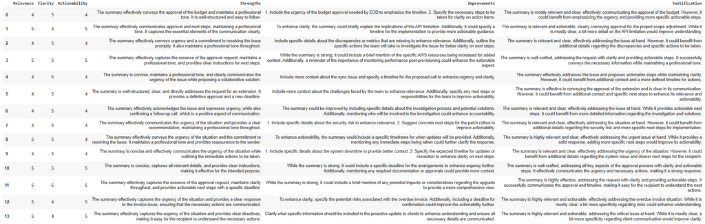

# **Task 4: Summary and Recommendation**

**Note:** Follow the instructions carefully and complete the missing sections.

In this task, you will write a **Summary and Recommendation** for the generated customer review response based on your understanding.

**Instructions:**

In this section, summarize the overall performance of the generated email summary across all tasks.

**1. Summary of Observations:**

- Briefly describe how the AI Email Secretary performed in summarizing emails.
- Highlight any patterns observed in the summaries (e.g., accuracy, level of detail, or any common errors).

**2. Evaluation Highlights:**

- Mention how the generated summaries performed on key dimensions:
  - Relevance: Did the summary capture the important points of the email?
  - Clarity: Was the summary easy to understand?
  - Actionability: Did the summary convey any next steps or actions required?

**3. Strengths:**

- List 2-3 strengths of the generated summaries (e.g., good at capturing action points, concise representation).

**4. Improvement Areas:**

- Suggest 1-2 areas where the AI Email Secretary can improve (e.g., missing certain details, inconsistent language).

**5. Final Recommendation:**

- Conclude with a recommendation on whether the current performance meets user needs or if further improvements are needed.

**Summary and Recommendation**

**Summary of Observations:**

The AI Email Secretary did a good job handling emails and picking up the key points from each message. The responses were accurate in understanding what the sender needed. In a few cases, the replies could have been stronger by adding more specific timelines or clearer follow-up steps.

**Evaluation Highlights:**

- **Relevance:** Scored 5/5 across almost all responses, showing the AI consistently understood and addressed the core message of each email.
- **Clarity:** Scored 5/5 consistently the language used was professional, simple, and easy to follow.
- **Actionability:** Scored mostly 4/5 the AI provided next steps but sometimes did not mention specific deadlines or what happens after.

**Strengths:**

- Responses were always on topic and directly addressed the sender's request.
- The language was clear and professional across all emails.
- Responses were concise and avoided unnecessary information.

**Improvement Areas:**

- Responses could be stronger by including specific deadlines for the actions mentioned.
- Some replies needed more detail on what the next step looks like in practice.

**Final Recommendation:**

The AI Email Secretary performs well and is ready for everyday business use. With small improvements around adding specific timelines and more detailed next steps, it can become a fully reliable tool for managing professional email communication.

**Sample Output Example**

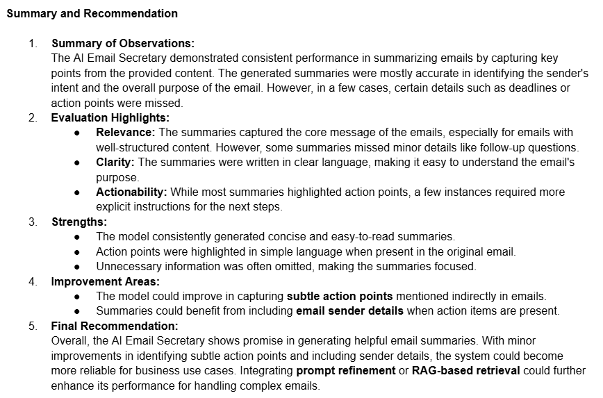

```python
# Save the notebook to HTML format
!jupyter nbconvert --to html --output "JHU_AGAI_W9_Mid_Term_Project_Learners_Notebook_12th_Feb.html" "/content/JHU_AGAI_W9_Mid_Term_Project_Solution_Notebook_12th_Feb.ipynb"
```

```
[NbConvertApp] Converting notebook /content/JHU_AGAI_W9_Mid_Term_Project_Solution_Notebook_12th_Feb.ipynb to html
[NbConvertApp] Writing 9347617 bytes to /content/JHU_AGAI_W9_Mid_Term_Project_Learners_Notebook_12th_Feb.html
```